# COVID-Wellen - Wien und Bundesländer

Erich Neuwirth

28. April 2022

## Zusammenfassung

Ein Vergleich des Verlaufs der Inzidenzzahlen in den Bundesländern zeigt einige bemerkenswerte Unterschiede.

In der 1. Welle (Höhepunkt 29. März 2020) waren die Inzidenzen in Wien eher niedrig, die COVID-Todesfallzahlen lagen im Bundesdurchschnitt.

In der 2. Welle (Höhepunkt 13. November 2020) waren sowohl die Inzidenzen als auch die COVID-Todesfallzahlen in Wien meist niedriger als in den übrigen Bundesländern.

In der 3. Welle (Höhepunkt 29. März 2021) hatte Wien meist die höchsten Inzidenzen und (nach dem Burgenland) die zweithöchsten COVID-Todesfallzahlen.

In der 4. Welle (Höhepunkt 23. November 2021) galten in Wien deutlich schärfere Einschränkungen als in den anderen Bundesländern.

Wien kam deutlich besser als die übrigen Bundesländer durch diese Welle. Die Inzidenzen waren merkbar geringer, und die COVID-Todesfallzahlen waren deutlich niedriger als im Rest Österreichs. Während dieser Periode waren die COVID-Todesfallzahlen in Kärnten zeitweise mehr als 3x so hoch wie in Wien. In dieser Welle waren die Maßnahmen in Wien deutlich strenger als in den übrigen Bundesländern; das scheint Wirkung gezeigt zu haben.

In der 5. (Höhepunkt 2. Feber 2022) und der 6. (Höhepunkt 18. März 2022) Welle hatte Wien am Anfang und gegen Ende eher hohe Inzidenzen, zwischendurch aber eher niedrige. Diese etwas eigenartige Tendenz kann mit den zwei Freiluft-Großveranstaltungen in Zusammenhang stehen.

Knapp nach dem Inzidenz-Höchstwert am 18. März, gab es in Wien zwei Freiluft-Großveranstaltungen, nämlich ein Konzert am 19. März im Ernst-Happel-Stadion und ein Konzert am 25. März am Heldenplatz. Zu dieser Zeit gab es keine generelle Maskenpflicht mehr, und ein Großteil des Publikums trug trotz deutlicher Empfehlung der Veranstalter keine Masken.

Im Zeitraum nach diesen beiden Veranstaltungen nahm die Inzidenz in Wien ab, die Abnahme war aber merklich weniger ausgeprägt als in den anderen Bundesländern. Das ist natürlich kein Beweis, dass die Veranstaltungen diese Entwicklung verursacht haben, aber doch ein Hinweis, der nicht vernachlässigt werden sollte.

Es gab in Wien im Verlauf der COVID-Pandemie mehrere Demonstrationen von Maßnahmegegnern. Die Inzidenzkurven geben aber keine Hinweise auf eine Auswirkung dieser Demonstrationen auf die Ausbreitung der COVID-Infektion

## Einleitung

Die Pandemie ist in Österreich in mehreren Wellen verlaufen. Wir sehen uns an, wie sich die Zahlen in den einzelnen Bundesländern vor und nach den bundesweiten Spitzenwerten entwickelt haben.

*Anmerkung: Quelle Folgenden verwendeten Daten ist die AGES, die Daten stehen auf der [Website der AGES](https://covid19-dashboard.ages.at) im Downloadbereich zur Verfügung*

*Die von der Statistik Austria am 20. April 2022 veröffentlichten bereinigten Sterbefalldaten sind in diesen Bericht eingearbeitet.*

Der Verlauf der Inzidenzen für ganz Österreich seit Beginn der Pandemie:

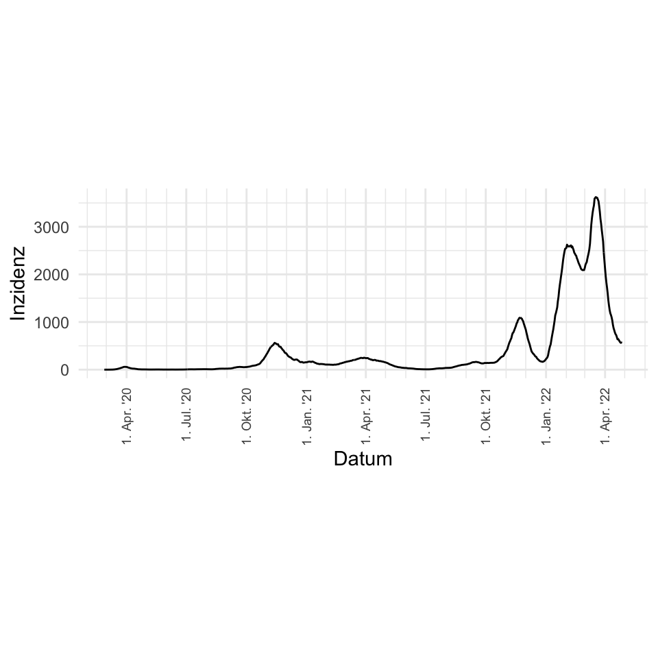

Wir sehen deutlich 6 Spitzen:

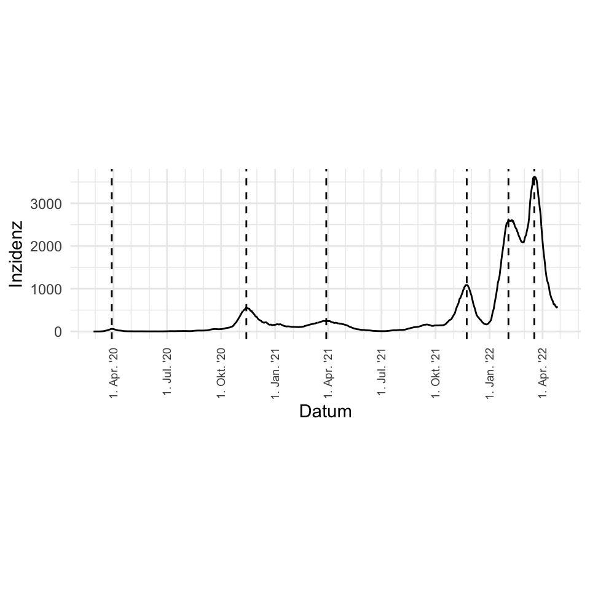

Die genauen Daten dieser Spitzen sind

| Welle | Datum | Variante |
| --- | --- | --- |
| 1 | 29. Mär. '20 | Wildtyp |
| 2 | 13. Nov. '20 | Wildtyp |
| 3 | 29. Mär. '21 | Alpha |
| 4 | 23. Nov. '21 | Delta |
| 5 | 2. Feb. '22 | Omikron |
| 6 | 18. Mär. '22 | Omikron |

Die Spitzen sind deutlich verschieden hoch. Auf einer logarithmischen Skala können wir die prozentuellen Zu- und Abnahmen der Werte besser erkennen.

[interactive chart not shown]

Wir sehen eine exponentielle Wachstumsphase von Anfang Juli 2020 bis Mitte November 2020. Dieses Wachstum wird allerdings mehrmals von Beruhigungsphasen unterbrochen.

## Inzidenzen und COVID-Todesfälle

Im folgenden untersuchen wir den Verlauf der Inzidenzen in den Bundesländern in der Zeit von 3 Wochen vor bis 5 Wochen nach den Spitzen. Die längere Nachlaufzeit nach der Spitze ist notwendig, weil die Todesfallzahlen den Inzidenzen erst mit Verzögerung folgen.

Wenn wir die Inzidenzen und die Zahlen der Todesfälle gemeinsam betrachten, dann ergibt sich folgendes Bild:

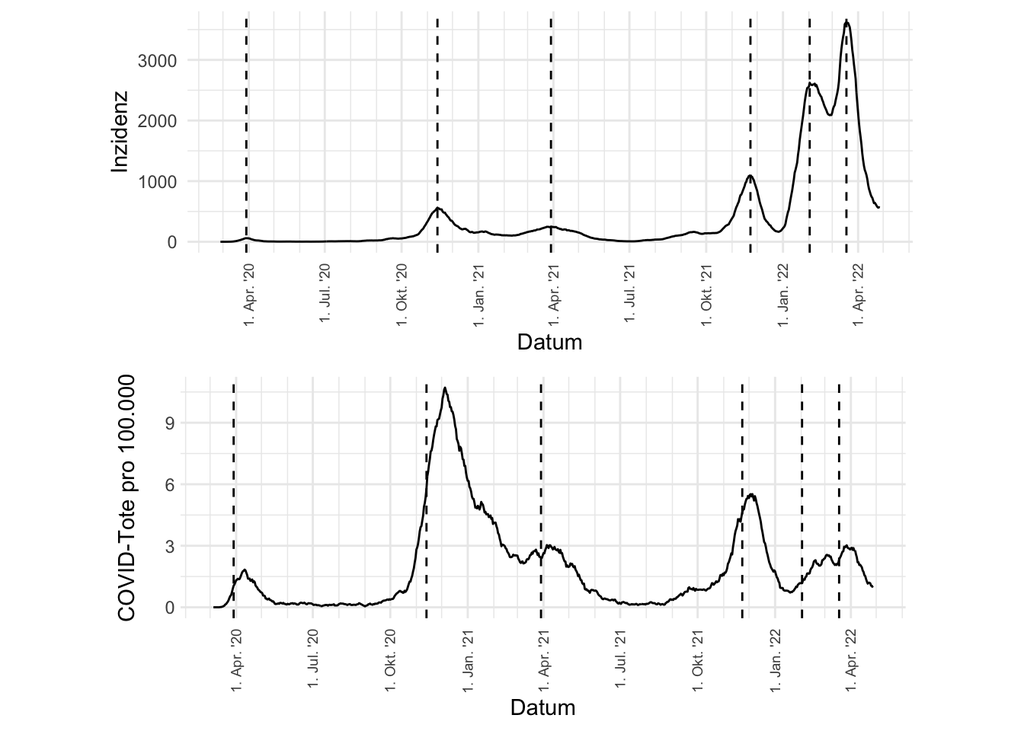

Die Zahl der COVID-Todesfälle ist in der 1. vergleichsweise niedrig und in der 2. Welle am höchsten. In der 3. Welle ist diese Zahl wieder niedrig und steigt in der 4. Welle wieder, aber nur halb so hoch wie der Höchstwert der 2. Welle. In der 5. und in der 6. Welle - die bezüglich der COVUD-Todesfallzahlen nicht mehr zu trennen sind - steigen die Zahlen noch einmal auf das Niveau der 3. Welle.

## Inzidenzen und COVID-Todesfälle in den Bundesländern

*Anmerkung: In den folgenden Abschnitten werden die in den verschiedenen Wellen vorgeschriebenen Schutzmaßnahmen beispielhaft - aber nicht vollständig - angeführt*

### 1. Welle Frühjahr 2020, Wildtyp

[interactive chart not shown]

*Anmerkung: Die Namen in der Legende sind in dieser und den folgenden Grafiken nach den höchsten Inzidenzen der Bundesländer geordnet.*

*Die Grafiken mit Kurven für die Bundesländer sind interaktiv, wenn der Mauszeiger auf eine Kurve geführt wird, dann wird diese Kurve hervorgehoben und das Bundesland angezeigt*

Während dieser 1. Welle gab es österreichweit die gleichen Einschränkungen:

- Physische Distanzregel (Babyelefant)
- Absage von Veranstaltungen
- Schul- und Universitätsschließungen
- Einschränkungen für Geschäfte und Restaurants
- Verbot des Betretens öffentlicher Orte
- MNS-Maskenpflicht ab 30. März 2020

In der ersten Welle waren zum Zeitpunkt die Inzidenzen in den westlichen Bundesländern Tirol, Salzburg und Vorarlberg (also Bundesländer mit Skigebieten) besonders hoch, 3 Wochen nach dem Spitzenwert waren die Unterschiede zwischen den Bundesländern aber nur mehr gering.

Die Werte nahmen in Tirol gegen Ende der Welle sehr stark ab, in den anderen Bundesländern war der Verlauf der Abnahme ziemlich gleich. Wien hatte gegen Ende des untersuchten Zeitraums eine geringere Abnahme als die anderen Bundesländer zu verzeichnen.

Die COVID-Todesfälle erreichen den Spitzenwert ungefähr 2 Wochen nach den Inzidenzen. Auch hier hat Tirol die allerhöchsten Werte, Wien liegt im Mittelfeld.

### 2. Welle Herbst 2020, Wildtyp

[interactive chart not shown]

Seit Mitte September 2020 gab es folgende Maßnahmen

- Maskenpflicht in Handel, Gastronomie und öffentlich zugänglichen geschlossenen Räumen
- Maskenpflicht auch im Freien, z.B. auf Märkten
- Beschränkung der Größe von Besuchergruppen in der Gastronomie
- Konsumation in der Gastronomie nur sitzend an Tischen
- Beschränkung der Anzahl von Personen bei Zusammenkünften
- Lockdown light ab 3. November (Ausgangsbeschränkungen zwischen 20 und 6 Uhr)
- Harter Lockdown ab 17. November (Ausgangsbeschränkungen den ganzen Tag, Ausnahmen für Notfälle)

Auch in der 2. Welle waren die Inzidenzen in Westösterreich und dazu noch in Oberösterreich besonders hoch. Die Abnahme nach der Spitze war in diesen Bundesländern ausgeprägter als in den übrigen Bundesländern. In Niederösterreich fiel der Rückgang der Inzidenzen deutlich schwächer aus als in den anderen Bundesländern. Wien hatte vor dem Spitzenwert eine im Vergleich zu den anderen Bundesländern eher hohe Inzidenz, nach dem Spitzenwert hatte Wien die niedrigste Inzidenz aller Bundesländer.

In dieser Welle kam es im Vergleich zu den anderen Wellen zu den höchsten COVID-Todesfallzahlen.

Die Todesfälle erreichen die Spitzenwerte mit einer Verzögerung von etwas mehr als 2 Wochen.

Der steile Anstieg der Wiener Zahlen dürfte auf einen Schub von Nachmeldungen zurückzuführen sein. Unter den Bundesländern hatte Kärnten die höchsten Todesfallzahlen.

### 3. Welle Frühjahr 2021, Alpha

[interactive chart not shown]

Österreichweit folgende Einschränkungen:

- Ausgangsbeschränkungen ganztägig
- Körpernahe Dienstleister, Zoos und Museen geschlossen
- Alle Geschäfte außer Geschäften, mit Gütern des täglichen Bedarfs geschlossen
- Distance Learning in Schulen ab 6. April
- Zusätzlich in Wien an einzelnen stark belebten Plätzen Maskenpflicht

Ab 1. April 2021 (Gründonnerstag) wurden die Lockdown-Regeln aufgrund der schlechten Situation in den Spitälern in Ostösterreich (Wien, Niederösterreich und Burgenland) über Ostern bis 11. April weiter verschärft.

In diesen 3 Bundesländern war der Rückgang der Inzidenzen um einiges deutlicher ausgeprägt als in den anderen Bundesländern. In Vorarlberg kam es gegen Ende dieser Periode sogar zu einem starken Anstieg der Inzidenz.

Bei den Todesfallzahlen gibt es in keinem Bundesland mit Ausnahme des Burgenlands eine deutlich ausgeprägte Spitze.

In Wien kam es trotz der schärferen Lockdown-Regeln zu keiner deutlichen Verringerung der Zahl der Todesfälle.

Im Burgenland gibt es zu Beginn der Welle einen ausgeprägten Anstieg, dann mehrere Wochen hindurch gleichmäßig hohe Werte und am Ende der Welle wieder einen ausgeprägten Rückgang.

### 4. Welle Herbst 2021, Delta

[interactive chart not shown]

In dieser Welle gab es erstmals in Wien schärfere Maßnahmen als in den anderen Bundesländern.

Gesamtösterreichische Maßnahmen:

- Ab 15. September 2021 FFP2-Maskenpflicht im Lebensmittelhandel, in Apotheken, Trafiken und öffentlichen Verkehrsmitteln.
- Ab 8. November 2G-Regel für Aufenthalt im öffentlichen Raum (Gastronomie und Nachtgastronomie eingeschlossen)
- Ausnahme: (Schwächere) 3G-Regel am Arbeitsplatz
- Stärkere Einschränkungen für Ungeimpfte: Ausgangsbeschränkung falls nicht 2G
- FFP2-Masken-Pflicht

Verschärfte Maßnahmen in Wien:

- 2G+-Regel statt 2G-Regel ab 16. November, also ist zum Nachweis von geimpft oder genesen auch ein negativer PCR-Test notwendig
- Homeoffice wird im Bereich der Gemeindeverwaltung stark forciert
- FFP2-Maskenpflicht ausgeweitet, z.B. wird diese Pflicht in der Gastronomie nur für die Dauer des Sitzens an einem Tisch aufgehoben

Ab 22. November trat österreichweit noch eine verschärfte Ausgangsbeschränkung in Kraft.

In dieser Welle schneidet Wien den ganzen Verlauf hindurch deutlich besser ab als die anderen Bundesländer, und zwar sowohl bei den Inzidenzen als auch bei den Fallzahlen. Die im Vergleich zu den anderen Bundesländern schärferen Maßnahmen scheinen also positive Wirkung gezeigt zu haben.

Besonders hohe COVID-Todesfallzahlen gibt es in Kärnten.

### 5. und 6. Welle Winter 2022, Omikron

Wir betrachten die 5. und die 6. Welle gemeinsam, weil diese beide Wellen sehr knapp hintereinander liegen und der Anstieg der Todesfälle der 5. Welle schon mit dem Beginn der 6. Welle überlappt.

[interactive chart not shown]

Gesamtösterreichische Maßnahmen:

- Lockdown für Ungeimpfte
- Sperrstunde Gastgewerbe 23 Uhr
- Maskenpflicht bei Indoor-Zusammenkünften
- Krankenanstalten 2G+ für Besucher
- 3G am Arbeitsplatz
- PCR gilt 72 Stunden
- ab 23. März teilweise Lockerung

Zusätzliche Maßnahmen in Wien

- Reduzierte Besuchsmöglichkeiten in Krankenanstalten
- PCR gilt 48 Stunden
- 2G+ auch bei Veranstaltungen im Freien

In der 5. Welle treten die Spitzenwerte der Inzidenz in den Bundesländern zu etwas verschiedenen Zeitpunkten auf, insbesondere in Vorarlberg, Tirol und Salzburg etwas später.

Der Spitzenwert der 6. Welle tritt in Tirol etwas früher und in Wien etwas später als in den anderen Bundesländern auf.

Die Inzidenz Wiens liegt zu Beginn der 5. Welle und zum Ende der 6. Welle etwas höher als die der anderen Bundesländer, dazwischen jedoch tendenziell niedriger.

## Inzidenzen und Großdemonstrationen

Wir untersuchen nun den Verlauf der Inzidenzen vor und nach Großdemonstrationen.

### Demonstration am 11. April 2021

[interactive chart not shown]

Diese Grafik zeigt keine Änderung im Trend der Inzidenz nach der Demonstration.

### Demonstrationen am 20. November und am 4. Dezember 2021

[interactive chart not shown]

Diese Grafik zeige keine Änderung im Trend der Inzidenz nach der Demonstration.

### Demonstrationen am 8., 15. und 29. Jänner 2022

[interactive chart not shown]

Diese 3 Demonstrationen fanden vor dem Höhepunkt der 5. Welle statt, es ist aber keine ausgeprägte Auswirkung auf die Inzidenzentwicklung festzustellen.

Demonstrationen am 27. Feber und am 12. März 2022

[interactive chart not shown]

Diese 2 Demonstrationen fanden vor dem Höhepunkt der 6. Welle statt, auch hier ist keine ausgeprägte Auswirkung auf die Inzidenz festzustellen.

## Freiluft-Konzerte am 19. und am 25. März 2022

In der 2. Märzhälfte 2022 fanden 2 große Freiluftkonzerte statt. Es herrschte keine Maskenpflicht, die Veranstalter ersuchten die Teilnehmer aber nachdrücklich, freiwillig FFP2-Masken zu tragen. Der Großteil des Publikums tat das allerdings nicht.

Wir untersuchen daher die Frage, ob sich die Inzidenzen in zeitlicher Nähe zu diesen Konzerten merkbar auffällig entwickelt haben.

### Inzidenz aller Altersgruppen

Wir untersuchen zunächst den Verlauf der Inzidenzen aller Altersgruppen zusammengenommen.

[interactive chart not shown]

Wien hat vor den Konzerten die niedrigste Inzidenz aller Bundesländer. Während in allen Bundesländern außer Niederösterreich die Inzidenz nach dem ersten Konzert schon sinkt, steigt sie in Wien noch etwas. Nach dem zweiten Konzert sinkt die Inzidenz in Wien zwar, aber in deutlich geringerem Ausmaß als in den anderen Bundesländern.

### Inzidenz der Altersgruppe 15-44

Vermutlich gehört der überwiegende Teil des Konzertpublikums der Altersgruppe 15-44 an. Daher sehen wir uns auch die Inzidenzen in dieser Altersgruppe an.

[interactive chart not shown]

Die Entwicklung der Inzidenz in dieser Altersgruppe unterscheidet sich nicht wesentlich von der aller Altersgruppen gemeinsam. Bis zum ersten Konzert hat Wien eine deutlich geringere Inzidenz als die anderen Bundesländer. Nach dem ersten Konzert steigt die Inzidenz in Wien noch schwach, während sie in den anderen Bundesländern schon sinkt. Nach dem zweiten Konzert sinkt die Inzidenz in Wien in deutlich geringerem Maße als in den anderen Bundesländern.

Man kann also begründet vermuten (wenn auch nicht beweisen), dass die Menschenansammlungen bei den beiden Freiluft-Großkonzerten das Abklingen der 6. COVID-Welle in Wien verlangsamt haben.